# Analiza recenzji ze Steama - Jakub Bąk

Jakub Bąk

7 06 2021

# Analiza recenzji gry “To the moon” pobranych z platformy Steam

1. Cel badań:
- Celem badań było stworzenie analizy recenzji przykładowej gry z popularnej platformy do kupowania gier Steam. Wybrana gra ma tytuł “To the moon”. Głównymi bohaterami gry są dr Eva Rosalene i dr Neil Watts, którzy pracują dla Sigmund Corp. – firmy, która dzięki technologii zmiany wspomnień oferuje ludziom spełnienie swojego największego marzenia. Można to jednak zrobić, dopiero gdy dana osoba jest umierająca, gdyż fałszywe wspomnienia kolidują z prawdziwymi, co uniemożliwia prawidłowe funkcjonowanie. W ramach analizy pobrałem zestaw recenzji, dokonałem ich czyszczenia oraz wstępnej analizy, a następnie przeszedłem do analizy semantycznej. Wyodrębniłem najpopularniejsze słowa występujące w recenzji, stworzyłem chmurę słów, a także podliczyłem sentymenty i stworzyłem wykres kilku podstawowych emocji występujących w recenzjach.
2. Dlaczego akurat “To the moon”?
- Jest to gra z gatunku “Indie”, tj. jest to gra tworzona przez niezależne, najczęściej bardzo małe studio. Dzięki temu już na samym początku analizy likwiduje jeden z większych problemów, czyli automatycznie tworzonych przez boty recenzji. Pozwala mi to na wstępną selekcję recenzji, a także większe upewnienie się, że dane będą pisane przez prawdziwe osoby, co w analizie semantycznej jest kluczowe.
3. Przeprowadzone czynności badawcze
- W ramach analizy wykonałem kilka niezbędnych czynności podanych poniżej w kolejności wykonania:
  - Pobranie danych za pomocą web scrapera(napisanego w Pythonie, a znalezionego w ramach eksploracji tematu)
  - Wstępna obróbka danych
  - Zebranie podstawowych danych i przedstawienie ich za pomocą wykresów oraz tabel
  - Przygotowanie danych do analizy semantycznej
  - Wyodrębnienie najpopularniejszych słów
  - Stworzenie chmury słów
  - Obliczenie sentymentów dla każdej osoby
  - Wyodrębnienie emocji znajdujących się w recenzjach
  - Zbiór “ciekawostek”, który nie zmieściły się w głóWnej części analizy

# Główna część analizy tekstu

1. Wstępne przetworzenie danych

```r
library(dplyr)
library(tidyverse)
library(tidytext)
library(stopwords)
library(hunspell)
library(textstem)
library(stringi)
library(openxlsx)
library(janitor)
```

```r
library(ggplot2)
library(ggpubr)
library(tm)
library(SnowballC)
library(wordcloud)
library(RColorBrewer)
library(syuzhet)
data <- read.xlsx('Dane_steam_To_the_Moon.xlsx', sheet = 1, skipEmptyRows = TRUE)

df <- subset(data, select = -c(product_id, page, page_order, user_id, date))
```

Usuwamy te kolumny, ponieważ nie dostarczają nam żadnej wartości w dalszej części analizy.

```r
for(i in 1:nrow(df)){
  if(is.na(df$compensation[i])){
    df$compensation[i] <- 0
  }
  else{
    df$compensation[i] <- 1
  }
}
```

W tym kroku zmieniam zmienną ‘compensation’ na zmienną w zakresie 0/1 dla ułatwienia dalszej analizy. 0-> normalnie kupiona gra, 1-> gra otrzymana za darmo

W przypadku data rozbijam ją na rok oraz miesiąc(dzień odrzucam, ponieważ nie jest potrzebny w analizie). Zostało to wykonane w programie Excel już przy wstępnym czyszczeniu tam danych. Pozostała mi jednak zmiana miesięcy z wartości numerycznych na znaki, dla lepszego efektu wizualnego na wykresach i większej jego czytelności.

```r
df$month <- month.abb[df$month]
```

Następną czynnością we wstępnej obróbce danych jest zastąpienie danych ‘Na’ dla kolumny ‘found_funny’ na 0 dla łatwiejszej późniejszej analizy

```r
for (i in 1:nrow(df)){
  if(is.na(df$found_funny[i])){
    df$found_funny[i] <- 0
  }
}
```

Na samym końcu tej części zmieniam część klas zmiennych na typ ‘numerical’ i podsumowuje wszystkie zebrane dane.

```r
df$found_funny <- as.numeric(df$found_funny)
df$compensation <- as.numeric(df$compensation)
df$hours <- as.numeric(df$hours)

summary(df)
```

```
##  recommended         text               hours            username
##  Mode :logical   Length:2330        Min.   :   0.000   Length:2330
##  FALSE:125       Class :character   1st Qu.:   4.100   Class :character
##  TRUE :2205      Mode  :character   Median :   5.000   Mode  :character
##                                     Mean   :   8.805
##                                     3rd Qu.:   6.800
##                                     Max.   :4100.900
##                                     NA's   :1
##     products       early_access     found_funny       compensation
##  Min.   :    1.0   Mode :logical   Min.   :  0.000   Min.   :0.00000
##  1st Qu.:  123.2   FALSE:2330      1st Qu.:  0.000   1st Qu.:0.00000
##  Median :  277.5                   Median :  0.000   Median :0.00000
##  Mean   :  625.9                   Mean   :  3.017   Mean   :0.01974
##  3rd Qu.:  630.2                   3rd Qu.:  1.000   3rd Qu.:0.00000
##  Max.   :16877.0                   Max.   :425.000   Max.   :1.00000
##
##     month                year
##  Length:2330        Min.   :2012
##  Class :character   1st Qu.:2015
##  Mode  :character   Median :2016
##                     Mean   :2017
##                     3rd Qu.:2019
##                     Max.   :2021
##
```

2. Zebranie podstawowych danych

```r
df %>%
  mutate(each_year=year) %>%
  group_by(each_year) %>%
  count(each_year)
```

```
## # A tibble: 10 x 2
## # Groups:   each_year [10]
##    each_year     n
##        <dbl> <int>
##  1      2012    25
##  2      2013   119
##  3      2014   437
##  4      2015   314
##  5      2016   352
##  6      2017   247
##  7      2018   157
##  8      2019   107
##  9      2020   126
## 10      2021   446
```

Ten krok służy do późniejszego przedstawienia danych za pomocą histogramu

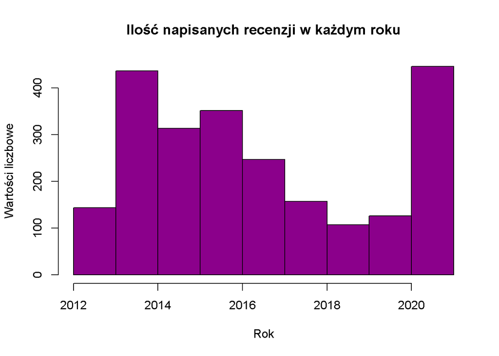

```r
Each_year <- df$year
hist(Each_year,
     main = 'Ilość napisanych recenzji w każdym roku',
     xlab = 'Rok',
     ylab = 'Wartości liczbowe',
     col = 'darkmagenta',
     breaks = c(2012, 2013, 2014, 2015, 2016, 2017, 2018, 2019, 2020, 2021))
```

Jak możemy zobaczyć, najwięcej recenzji pojawiło się w 2021 roku pomimo tego, że sama gra została dodana na Steama w 2011 roku. Może to jednak wynikać z filtrów zastosowanych w web scraperze(który był biased w stosunku do późniejszych lat), dlatego najbardziej prawdopodobny rok z największą ilością recenzji to rok 2014, co nadal jest mocno zaskakujące. Prawdopodobnie dopiero wtedy gra stała się naprawdę popularna. Wynika to też z tego, że druga gra studia “A bird story” ukazała się właśnie w 2014 roku co może być najbardziej prawdopodobnym wynikiem tego.

Analogicznie postępuje w przypadku miesięcy

```r
Each_month <- as.data.frame(table(df$month))
Each_month
```

```
##    Var1 Freq
## 1   Apr  193
## 2   Aug  124
## 3   Dec  233
## 4   Feb  277
## 5   Jan  271
## 6   Jul  159
## 7   Jun  223
## 8   Mar  201
## 9   May  211
## 10  Nov  230
## 11  Oct  116
## 12  Sep   92
```

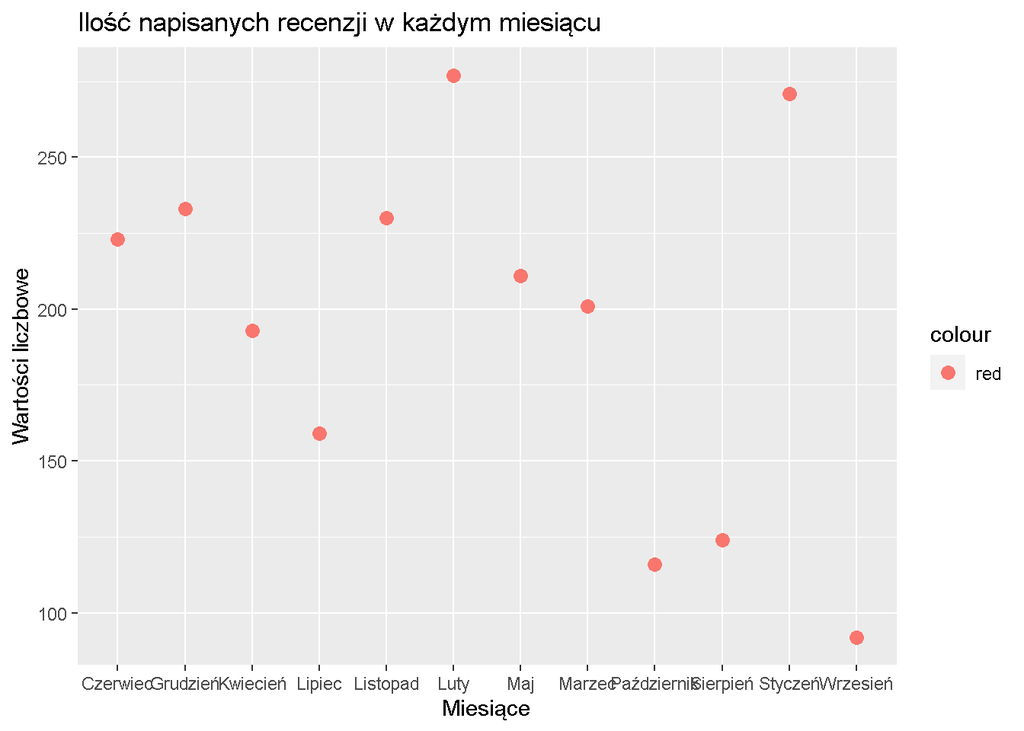

```r
months <- c('Styczeń', 'Luty', 'Marzec', 'Kwiecień', 'Maj', 'Czerwiec', 'Lipiec', 'Sierpień', 'Wrzesień', 'Październik', 'Listopad', 'Grudzień')
values <- c(271, 277, 201, 193, 211, 223, 159, 124, 92, 116, 230, 233)
Each_month_to_plot <- data.frame(months, values)

ggplot(Each_month_to_plot) + geom_point(aes(x = months, y = values, color = 'red'), size = 3.0) +
  xlab('Miesiące') +
  ylab('Wartości liczbowe') +
  ggtitle('Ilość napisanych recenzji w każdym miesiącu')
```

W tym miejscu liczę średnią ilość godzin na grę nie uwzględniając oraz uwzględniając skrajne przypadki, tj. 4100 godzin oraz 1153 godzin, które mocno zaburzają wartość średniej, o ponad 2 godziny, policzę dlatego jeszcze błąd względny.

```r
mean_hours <- mean(df$hours, na.rm = TRUE)
mean_hours
```

```
## [1] 8.80541
```

```r
mean_hours_without_extremes <- mean(df$hours[df$hours < 270], na.rm = TRUE)
mean_hours_without_extremes
```

```
## [1] 6.555049
```

```r
percentage_error <- ((mean_hours - mean_hours_without_extremes)/mean_hours) * 100
percentage_error
```

```
## [1] 25.55657
```

W tym wypadku wynosi on ponad 25%, co jest b. wysokim wynikiem. Następnie policzę średnią ilość produktów.

```r
mean_products <- mean(df$products, na.rm = TRUE)
mean_products
```

```
## [1] 625.8957
```

Wynosi ona ponad 625 gier na jedną osobę. Następnie policzę % osób, które poleciłoby tą grę.

```r
percentage_recommended <- (sum(df$recommended, na.rm = TRUE) / nrow(df)) * 100
percentage_recommended
```

```
## [1] 94.63519
```

Wychodzi on na prawie 95% co jest bardzo dobrym wynikiem jak na grę z tak dużą ilością recenzji. Ostatnią rzeczą jest policzenie ile średnio osób uważało daną recenzję za zabawną, pomijając recenzje, które takich wartości nie miały.

```r
mean_funny_reviews <- mean(df$found_funny[df$found_funny > 0], na.rm = TRUE)
mean_funny_reviews
```

```
## [1] 9.474394
```

```r
for(i in 1:nrow(df)){
  df$word_count[i] <- sapply(strsplit(df$text[i], " "), length)
}

mean_word_count <- mean(df$word_count, na.rm = TRUE)
mean_word_count
```

```
## [1] 74.9721
```

Na sam koniec połączę te wszystkie dane w jeden data frame

```r
variable <- c(mean_hours, mean_hours_without_extremes, percentage_error, mean_products, percentage_recommended, mean_funny_reviews, mean_word_count)
names <- c('mean_hours', 'mean_hours_without_extremes', 'percentage_error', 'mean_products', 'percentage_recommended', 'mean_funny_reviews', 'mean_word_count')

every_fact <- data.frame(names, variable)
every_fact
```

```
##                         names   variable
## 1                  mean_hours   8.805410
## 2 mean_hours_without_extremes   6.555049
## 3            percentage_error  25.556568
## 4               mean_products 625.895708
## 5      percentage_recommended  94.635193
## 6          mean_funny_reviews   9.474394
## 7             mean_word_count  74.972103
```

Następny wykres to wykres zależności między długością recenzji, a ilością godzin spędzonych nad grą.

```r
df$word_count <- as.numeric(df$word_count)
```

Jak możemy zobaczyć, godziny grania, a długość recenzji nie jest w żaden sposób skorelowana ze sobą.

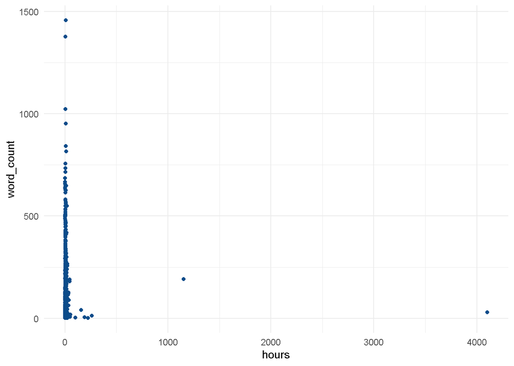

```r
ggplot(df) +
  aes(x = hours, y = word_count) +
  geom_point(colour = "#0c4c8a") +
  theme_minimal()
```

3. Analiza semantyczna recenzji

W tej części zająłem się analizą semantyczną recenzji, ale zacznę najpierw od ich wstępnego wyczyszczenia jak tokenizacja, usunięcie znaków stop oraz lematyzacji.

```r
tidied_text <- df %>%
  unnest_tokens(word, text)

tidied_text_2 <- tidied_text %>%
  anti_join(stop_words)
tidied_test_ultimate <- tidied_text_2 %>%
  mutate(word2 = hunspell_stem(word))
```

Następnym krokiem będzie podliczenie najbardziej popularnych słów występujących w recenzjach. Przedstawię je na wykresie słupkowym. Wcześniej jednak muszę usunąć te wiersze, w których występują nieznane znaki w celu lepszej przejrzystości.

```r
ultimate_most_popular_Words <- tidied_test_ultimate %>%
  count(word2) %>%
  arrange(desc(n))

head(ultimate_most_popular_Words)
```

```
##   word2     n
## 1       17989
## 2  game  4708
## 3 story  2413
## 4  play  1496
## 5  moon   803
## 6   cry   737
```

```r
ultimate_most_popular_Words <- ultimate_most_popular_Words[-c(1),]
```

Jak możemy zobaczyć, najbardziej popularnym słowem jest puste pole. Wynika to z tego, ze zamiast tego pola występują inne znaki niewystępujące w angielskim, dlatego będzie to potem pominięte w analizie oraz wykresach

[figure not shown]

```r
barplot(ultimate_most_popular_Words[1:6,]$n, las = 2, names.arg = ultimate_most_popular_Words[2:7,]$word2, col = 'darkgreen', main="Top 6 najczęściej występujących słów", ylab="Częstotliwość występowania")
```

Kolejnym krokiem jest stworzenie chmury słów, która jest dobrym sposobem na zwizualizowanie i analizę danych

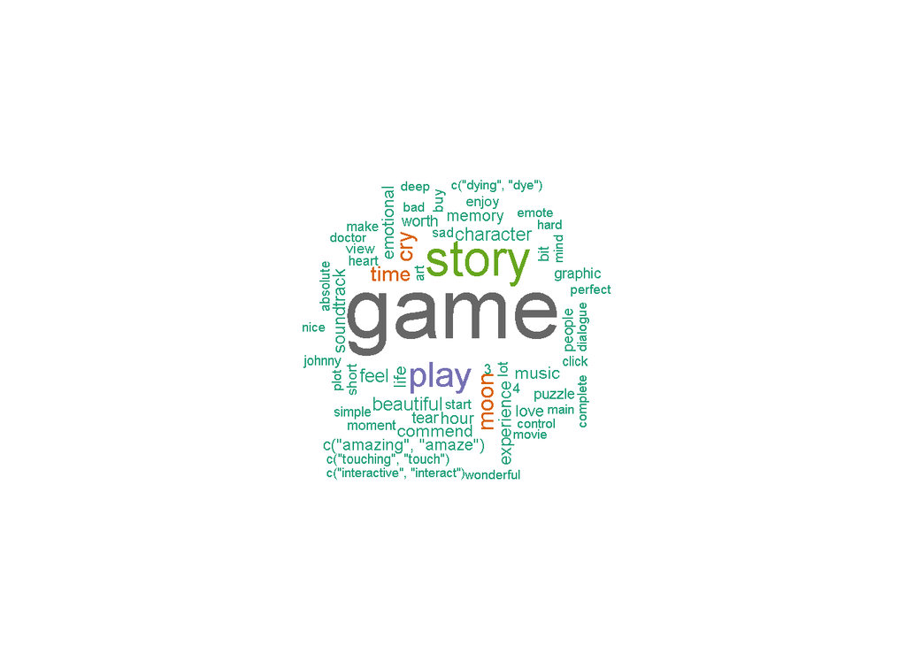

```r
set.seed(587)
wordcloud(words = ultimate_most_popular_Words$word2, freq = ultimate_most_popular_Words$n, min.freq = 10, max.words = 60, random.order = FALSE,
          rot.per = 0.30, colors=brewer.pal(8, "Dark2"))
```

W kolejnym kroku będę obliczał i zajmował się analizą sentymentów znajdujących się w tekście. W jej ramach korzystam ze słownika ‘bing’, a także sprawdzam sentyment dla każdego użytkownika, aby sprawdzić najbardziej i najmniej negatywne recenzje.

```r
tidied_test_ultimate_bing <- tidied_test_ultimate %>%
  inner_join(get_sentiments("bing"))
glimpse(tidied_test_ultimate_bing)
```

```
## Rows: 11,477
## Columns: 13
## $ recommended  <lgl> TRUE, TRUE, TRUE, TRUE, TRUE, TRUE, TRUE, TRUE, TRUE, ...
## $ hours        <dbl> 4.2, 4.2, 4.2, 4.2, 4.2, 4.2, 4.2, 4.2, 4.2, 4.2, 4.2,...
## $ username     <chr> "Jet Black", "Jet Black", "Jet Black", "Jet Black", "J...
## $ products     <dbl> 822, 822, 822, 822, 822, 822, 822, 822, 822, 822, 822,...
## $ early_access <lgl> FALSE, FALSE, FALSE, FALSE, FALSE, FALSE, FALSE, FALSE...
## $ found_funny  <dbl> 0, 0, 0, 0, 0, 0, 0, 0, 0, 0, 0, 0, 0, 0, 0, 0, 0, 0, ...
## $ compensation <dbl> 0, 0, 0, 0, 0, 0, 0, 0, 0, 0, 0, 0, 0, 0, 0, 0, 0, 0, ...
## $ month        <chr> "Jan", "Jan", "Jan", "Jan", "Jan", "Jan", "Jan", "Jan"...
## $ year         <dbl> 2014, 2014, 2014, 2014, 2014, 2014, 2014, 2014, 2014, ...
## $ word_count   <dbl> 339, 339, 339, 339, 339, 339, 339, 339, 339, 339, 339,...
## $ word         <chr> "wow", "brutally", "honest", "amazing", "creative", "h...
## $ word2        <list> ["wow", "brutal", <"honest", "hon">, <"amazing", "ama...
## $ sentiment    <chr> "positive", "negative", "positive", "positive", "posit...
```

```r
tidied_summary <- tidied_test_ultimate_bing %>%
  group_by(username) %>%
  count(sentiment) %>%
  spread(sentiment, n, fill = 0) %>%
  mutate(sentiment = positive - negative)
```

Ogólny sentyment pozytywny to 3108, a ogólny sentyment negatywny to -1281

```r
sentiment_table <- table(tidied_summary$sentiment)
sentiment_table
```

```
##
## -54 -38 -20 -18 -14 -13 -12 -11 -10  -9  -8  -7  -6  -5  -4  -3  -2  -1   0   1
##   1   1   1   1   2   2   3   2   3   3   6   8  17  21  31  39 115 200 181 367
##   2   3   4   5   6   7   8   9  10  11  12  13  14  15  16  18  19  22
## 256 150 115  68  46  18  18  11   6   4   2   4   1   1   3   2   1   1
```

Dodatkowo jak możemy zobaczyć w tabeli, wyniki oscylowały wokół 0, były raczej neutralnie nastawione do samej gry, co może dziwić, kiedy weźmie się pod uwagę jej pozytywne rekomendacje. Jednak należy wziąć tutaj pod uwagę nastrój gry. Jest ona zdecydowanie melancholijna, a więc słowa jak ‘cry’ czy ‘sad’, które często się pojawiały nie miały znaczenia negatywnego, ale pozytywny, dlatego warto mieć to na uwadze przy analizie tekstów, które mają być z założenia smutne.

Na sam koniec przeprowadzę klasyfikacje emocji każdej z recenzji, aby sprawdzić jakie emocje dominują w niej.

```r
text <- df$text
d<-get_nrc_sentiment(text)
head (d,10)
```

```
##    anger anticipation disgust fear joy sadness surprise trust negative positive
## 1      2           10       2    6   9       5        3     7        8       15
## 2      4            6       4    4   8       5        5     9        9       13
## 3     12           25       3   12  20      15        9    16       30       40
## 4      0            0       0    0   0       1        0     0        1        0
## 5      0            0       0    0   0       0        0     0        0        0
## 6      0            3       0    0   2       1        2     1        3        4
## 7      0            2       2    0   1       3        0     1        3        1
## 8      1            0       1    0   0       2        0     0        2        0
## 9      0           11       2    1  16       4        6    16       10       31
## 10     0            1       0    0   0       0        0     0        0        1
```

Aby móc te dane zwizualizować, najpierw będę transponował tabelę, zliczy wystąpienia każdej z emocji, wyczysczę ją, a na sam koniec stworzę plota, który to będzie lepiej obrazował.

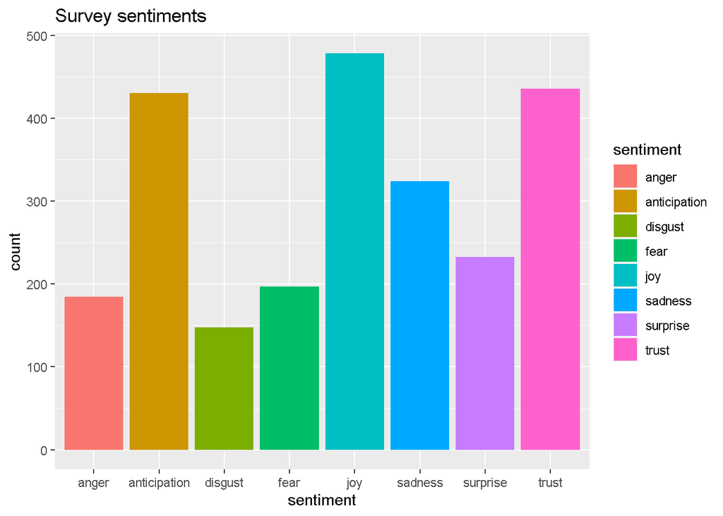

```r
td<-data.frame(t(d))
td_new <- data.frame(rowSums(td[2:253]))
names(td_new)[1] <- "count"
td_new <- cbind("sentiment" = rownames(td_new), td_new)
rownames(td_new) <- NULL
td_new2<-td_new[1:8,]

quickplot(sentiment, data=td_new2, weight=count, geom="bar", fill=sentiment, ylab="count")+ggtitle("Survey sentiments")
```

Dominującymi emocjami są ‘joy’, ‘trust’, ‘anticipation’ oraz ‘sadness’.

Na sam koniec analizy stworzę barplota, który pokaże jak to wyglądało procentowo

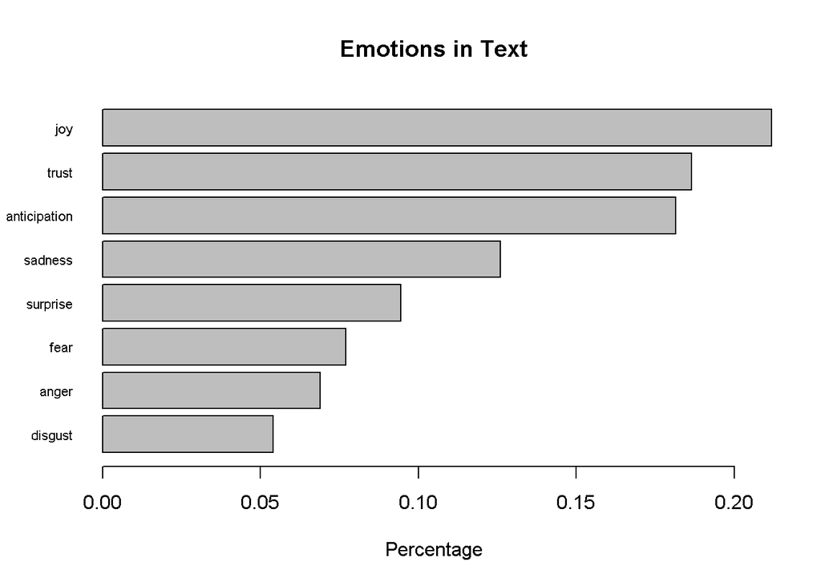

```r
barplot(
  sort(colSums(prop.table(d[, 1:8]))),
  horiz = TRUE,
  cex.names = 0.7,
  las = 1,
  main = "Emotions in Text", xlab="Percentage"
)
```